# hw4

Ekrem Barış Kuyucu

22 01 2021

## Introduction

We want to forecast the electricity consumption for 14 days ahead. To do this we will use the data from 1 January 2017 to 8 January 2021. We need a stationary data in order to have good forecast values. We will analyze the data and try to find the values which disrupt our data’s stationarity. We have some idea that some special holidays may have an effect on these values. We will plot our data and add some parameters to our model, then see whether we can see it easily the data that disrupt our data’s stationarity.

```r
library(data.table)
library(lubridate)
library(zoo)
library(forecast)
library(mgcv)
```

```r
library(urca)
library(ggplot2)
library(gratia)
```

We read our data with fread function. We have to convert date values to date because they were char values. Also our data used “.” for indicating that a number is more than a thousand we need to erase that. Then our csv file used “,” for decimal points, so we need to convert it to “.” in order to use the data more efficiently. Then we see the first 25 data whether our data looks like we wanted.

```r
consumption<-fread("D:/Boğaziçi/İe360/data/hw4/RealTimeConsumption-01012017-08012021.csv")

consumption[,Date:=as.Date(Date,format = "%d.%m.%Y")]
consumption[,Consumption:=gsub('\\,','\\',Consumption)]
consumption[,Consumption:=as.numeric(Consumption)]
head(consumption,25)
```

```
##           Date  Hour Consumption
##  1: 2017-01-01 00:00    27223.06
##  2: 2017-01-01 01:00    25825.90
##  3: 2017-01-01 02:00    24252.68
##  4: 2017-01-01 03:00    22915.47
##  5: 2017-01-01 04:00    22356.99
##  6: 2017-01-01 05:00    22274.49
##  7: 2017-01-01 06:00    22388.61
##  8: 2017-01-01 07:00    22608.23
##  9: 2017-01-01 08:00    22547.94
## 10: 2017-01-01 09:00    23844.14
## 11: 2017-01-01 10:00    25667.71
## 12: 2017-01-01 11:00    27186.13
## 13: 2017-01-01 12:00    28002.60
## 14: 2017-01-01 13:00    28618.02
## 15: 2017-01-01 14:00    28694.90
## 16: 2017-01-01 15:00    28558.29
## 17: 2017-01-01 16:00    29146.36
## 18: 2017-01-01 17:00    30628.06
## 19: 2017-01-01 18:00    32342.00
## 20: 2017-01-01 19:00    32254.23
## 21: 2017-01-01 20:00    31780.44
## 22: 2017-01-01 21:00    31277.52
## 23: 2017-01-01 22:00    30689.53
## 24: 2017-01-01 23:00    29308.57
## 25: 2017-01-02 00:00    27477.70
##           Date  Hour Consumption
```

## Visualization

Our data is hourly. We want to use daily data for our forecast. So we need to calculate the mean consumption of each day and combine them into a daily parameter. Then we plot our daily data to see how it shows seasonalities to us. In order to see the seasonalities even better we use difference between a day and 7 days before that day and with its plot we can see the seasonalities even better. We use kpss to see our test statistic value. It seems reasonable but we will try to find a better value.

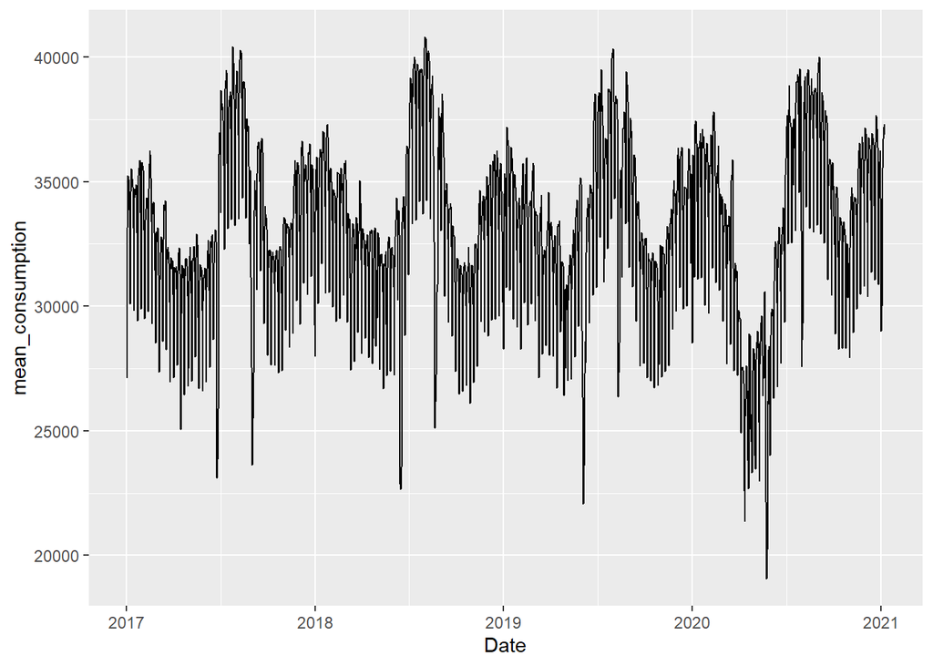

```r
daily_consumption<-consumption[,list(mean_consumption=mean(Consumption,na.rm=T)),by=list(Date)]
ggplot(daily_consumption,aes(x=Date))+ geom_line(aes(y=mean_consumption))
```

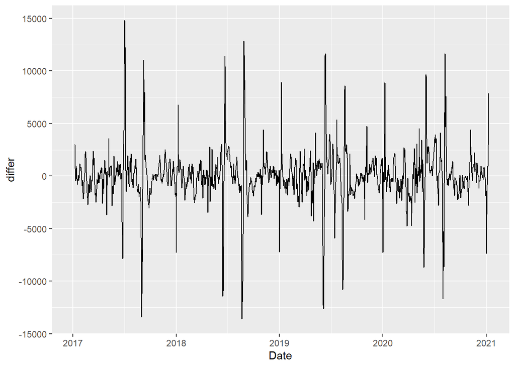

```r
daily_consumption[,differ:=mean_consumption-shift(mean_consumption,7)]
ggplot(daily_consumption,aes(x=Date)) + geom_line(aes(y=differ))
```

```r
daily_consumption[,w_day:=weekdays(Date)]
daily_consumption[,y_day:=yday(Date)]
daily_consumption[,mon:=months(Date)]
daily_consumption[,time_index:=1:.N]

unt_test=ur.kpss(daily_consumption$mean_consumption)
summary(unt_test)
```

```
##
## #######################
## # KPSS Unit Root Test #
## #######################
##
## Test is of type: mu with 7 lags.
##
## Value of test-statistic is: 0.1457
##
## Critical value for a significance level of:
##                 10pct  5pct 2.5pct  1pct
## critical values 0.347 0.463  0.574 0.739
```

## Analysis

We defined some special days and holidays and looked their values from our data. In these days which are defined below, our daily consumption values are lower than our usual values that are before and after some these days. So we may say that they create seasonality over time.

```r
daily_consumption[,yeni_yil:=0]
daily_consumption[Date %in% as.Date(c("2017-01-01","2018-01-01","2019-01-01","2020-01-01","2021-01-01")),yeni_yil:=1]

daily_consumption[,yeni_yil1:=yeni_yil-shift(yeni_yil,7)]

daily_consumption[,yirmi_uc_nisan:=0]
daily_consumption[Date %in% as.Date(c("2017-04-23","2018-04-23","2019-04-23","2020-04-23")),yirmi_uc_nisan:=1]

daily_consumption[,yirmi_uc_nisan1:=yirmi_uc_nisan-shift(yirmi_uc_nisan,7)]

daily_consumption[,on_dokuz_mayis:=0]
daily_consumption[Date %in% as.Date(c("2017-05-19","2018-05-19","2019-05-19","2020-05-19")),on_dokuz_mayis:=1]

daily_consumption[,on_dokuz_mayis1:=on_dokuz_mayis-shift(on_dokuz_mayis,7)]

daily_consumption[,bir_mayis:=0]
daily_consumption[Date %in% as.Date(c("2017-04-30","2017-05-01","2018-05-01","2019-05-01","2020-05-01")),bir_mayis:=1]

daily_consumption[,bir_mayis1:=bir_mayis-shift(bir_mayis,7)]

daily_consumption[,on_bes_temmuz:=0]
daily_consumption[Date %in% as.Date(c("2018-07-15","2019-07-15")),on_bes_temmuz:=1]

daily_consumption[,on_bes_temmuz1:=on_bes_temmuz-shift(on_bes_temmuz,7)]

daily_consumption[,yirmi_dokuz_ekim:=0]
daily_consumption[Date %in% as.Date(c("2017-10-29","2018-10-28","2018-10-29","2019-10-27","2019-10-28","2019-10-29")),yirmi_dokuz_ekim:=1]

daily_consumption[,yirmi_dokuz_ekim1:=yirmi_dokuz_ekim-shift(yirmi_dokuz_ekim,7)]

daily_consumption[,ramazan_bayrami:=0]
daily_consumption[Date %in% as.Date(c("2017-06-24","2017-06-25","2017-06-26","2017-06-27","2018-06-14","2018-06-15","2018-06-16","2018-06-17","2019-06-02","2019-06-03","2019-06-04","2019-06-05","2019-06-06","2019-06-07","2019-06-08","2019-06-09","2020-05-23","2020-05-24","2020-05-25","2020-05-26")),ramazan_bayrami:=1]

daily_consumption[,ramazan_bayrami1:=ramazan_bayrami-shift(ramazan_bayrami,7)]

daily_consumption[,kurban_bayrami:=0]
daily_consumption[Date %in% as.Date(c("2017-08-31","2017-09-01","2017-09-02","2017-09-03","2017-09-04","2018-08-20","2018-08-21","2018-08-22","2018-08-23","2018-08-24","2019-08-11","2019-08-12","2019-08-13","2019-08-14","2020-07-31","2020-08-01","2020-08-02","2020-08-03")),kurban_bayrami:=1]

daily_consumption[,kurban_bayrami1:=kurban_bayrami-shift(kurban_bayrami,7)]

daily_consumption[,covid19:=0]
daily_consumption[Date>="2020-05-01" & Date<="2020-07-01" ,covid19:=1]

daily_consumption[,covid:=covid19-shift(covid19,7)]
```

We look at the autocorrelation and partial autocorrelation function of our data with the mean consumption. Then we need to define the days which we are going to forecast. We must add these dates to our data because if we don’t we can’t forecast. After adding these 14 days we need to add our previously defined parameters again because the forecasted days won’t have them.

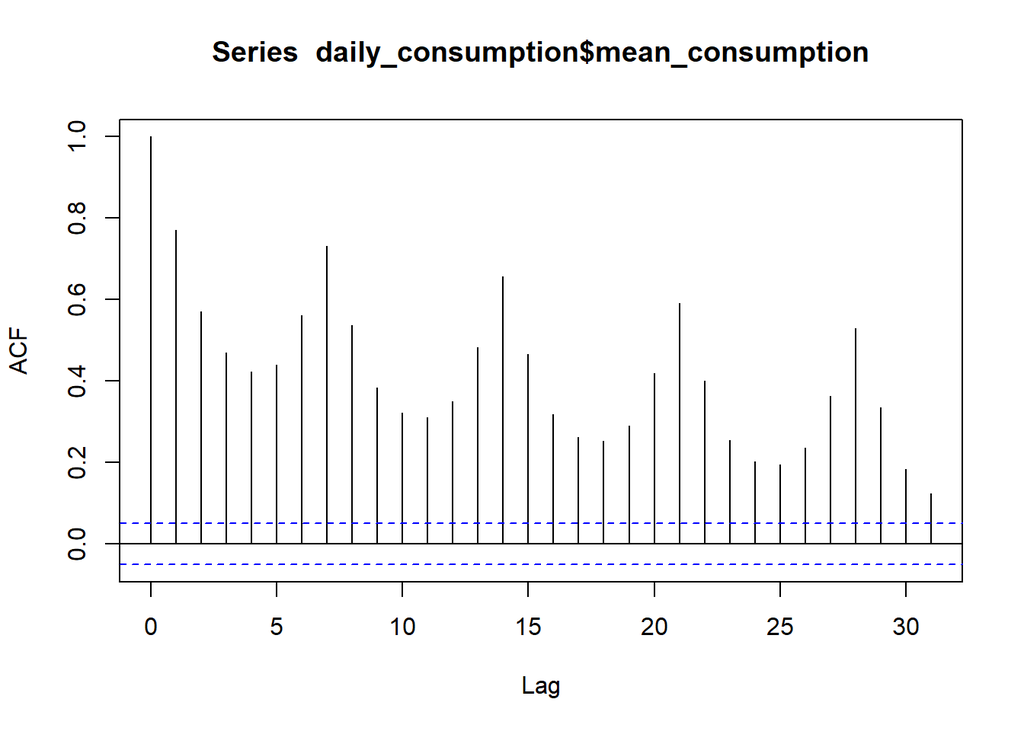

```r
acf(daily_consumption$mean_consumption)
```

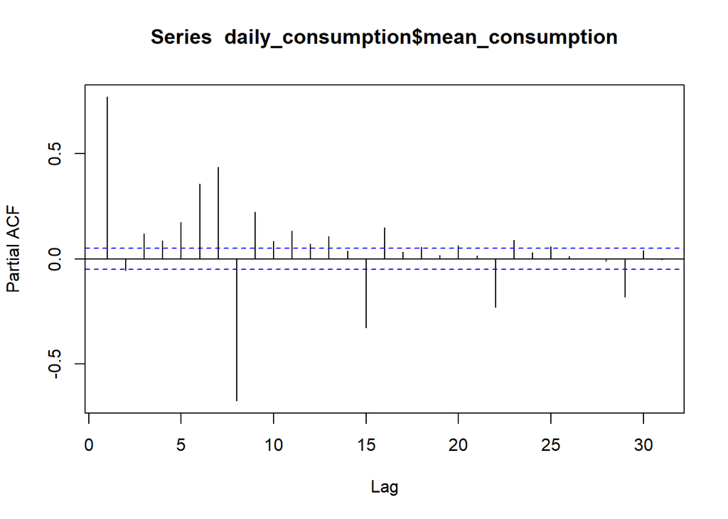

```r
pacf(daily_consumption$mean_consumption)
```

```r
reg1<-cbind(as.factor(daily_consumption$w_day),as.factor(daily_consumption$mon),as.factor(daily_consumption$y_day),daily_consumption$time_index,daily_consumption$yeni_yil1,daily_consumption$yirmi_uc_nisan1,daily_consumption$bir_mayis1,daily_consumption$on_bes_temmuz1,daily_consumption$yirmi_dokuz_ekim1,daily_consumption$ramazan_bayrami1,daily_consumption$kurban_bayrami1,daily_consumption$covid)

fitted1<-auto.arima(daily_consumption$differ,xreg=reg1,seasonal=F,trace=T)
```

```
##
##  Fitting models using approximations to speed things up...
##
##  ARIMA(2,0,2) with non-zero mean : 24454.63
##  ARIMA(0,0,0) with non-zero mean : 25506.01
##  ARIMA(1,0,0) with non-zero mean : 24528.92
##  ARIMA(0,0,1) with non-zero mean : 24887.52
##  ARIMA(0,0,0) with zero mean     : 25534.99
##  ARIMA(1,0,2) with non-zero mean : 24486.51
##  ARIMA(2,0,1) with non-zero mean : 24460.42
##  ARIMA(3,0,2) with non-zero mean : 24440.08
##  ARIMA(3,0,1) with non-zero mean : 24445.94
##  ARIMA(4,0,2) with non-zero mean : 24240.51
##  ARIMA(4,0,1) with non-zero mean : 24425.14
##  ARIMA(5,0,2) with non-zero mean : Inf
##  ARIMA(4,0,3) with non-zero mean : 24361.06
##  ARIMA(3,0,3) with non-zero mean : 24322.12
##  ARIMA(5,0,1) with non-zero mean : 24438.47
##  ARIMA(5,0,3) with non-zero mean : 24279.12
##  ARIMA(4,0,2) with zero mean     : 24242.25
##
##  Now re-fitting the best model(s) without approximations...
##
##  ARIMA(4,0,2) with non-zero mean : Inf
##  ARIMA(4,0,2) with zero mean     : Inf
##  ARIMA(5,0,3) with non-zero mean : Inf
##  ARIMA(3,0,3) with non-zero mean : Inf
##  ARIMA(4,0,3) with non-zero mean : Inf
##  ARIMA(4,0,1) with non-zero mean : 24432.34
##
##  Best model: Regression with ARIMA(4,0,1) errors
```

```r
forecast_dates<-c("2021-01-09","2021-01-10","2021-01-11","2021-01-12","2021-01-13","2021-01-14","2021-01-15","2021-01-16","2021-01-17","2021-01-18","2021-01-19","2021-01-20","2021-01-21","2021-01-22")

daily_consumption<-rbind(daily_consumption,data.table(Date=as.Date(forecast_dates)),fill=T)

daily_consumption[,w_day:=weekdays(Date)]
daily_consumption[,y_day:=yday(Date)]
daily_consumption[,mon:=months(Date)]
daily_consumption[,time_index:=1:.N]

daily_consumption[,yeni_yil:=0]
daily_consumption[Date %in% as.Date(c("2017-01-01","2018-01-01","2019-01-01","2020-01-01","2021-01-01")),yeni_yil:=1]

daily_consumption[,yeni_yil1:=yeni_yil-shift(yeni_yil,7)]

daily_consumption[,yirmi_uc_nisan:=0]
daily_consumption[Date %in% as.Date(c("2017-04-23","2018-04-23","2019-04-23","2020-04-23")),yirmi_uc_nisan:=1]

daily_consumption[,yirmi_uc_nisan1:=yirmi_uc_nisan-shift(yirmi_uc_nisan,7)]

daily_consumption[,on_dokuz_mayis:=0]
daily_consumption[Date %in% as.Date(c("2017-05-19","2018-05-19","2019-05-19","2020-05-19")),on_dokuz_mayis:=1]

daily_consumption[,on_dokuz_mayis1:=on_dokuz_mayis-shift(on_dokuz_mayis,7)]

daily_consumption[,bir_mayis:=0]
daily_consumption[Date %in% as.Date(c("2017-04-30","2017-05-01","2018-05-01","2019-05-01","2020-05-01")),bir_mayis:=1]

daily_consumption[,bir_mayis1:=bir_mayis-shift(bir_mayis,7)]

daily_consumption[,on_bes_temmuz:=0]
daily_consumption[Date %in% as.Date(c("2018-07-15","2019-07-15")),on_bes_temmuz:=1]

daily_consumption[,on_bes_temmuz1:=on_bes_temmuz-shift(on_bes_temmuz,7)]

daily_consumption[,yirmi_dokuz_ekim:=0]
daily_consumption[Date %in% as.Date(c("2017-10-29","2018-10-28","2018-10-29","2019-10-27","2019-10-28","2019-10-29")),yirmi_dokuz_ekim:=1]

daily_consumption[,yirmi_dokuz_ekim1:=yirmi_dokuz_ekim-shift(yirmi_dokuz_ekim,7)]

daily_consumption[,ramazan_bayrami:=0]
daily_consumption[Date %in% as.Date(c("2017-06-24","2017-06-25","2017-06-26","2017-06-27","2018-06-14","2018-06-15","2018-06-16","2018-06-17","2019-06-02","2019-06-03","2019-06-04","2019-06-05","2019-06-06","2019-06-07","2019-06-08","2019-06-09","2020-05-23","2020-05-24","2020-05-25","2020-05-26")),ramazan_bayrami:=1]

daily_consumption[,ramazan_bayrami1:=ramazan_bayrami-shift(ramazan_bayrami,7)]

daily_consumption[,kurban_bayrami:=0]
daily_consumption[Date %in% as.Date(c("2017-08-31","2017-09-01","2017-09-02","2017-09-03","2017-09-04","2018-08-20","2018-08-21","2018-08-22","2018-08-23","2018-08-24","2019-08-11","2019-08-12","2019-08-13","2019-08-14","2020-07-31","2020-08-01","2020-08-02","2020-08-03")),kurban_bayrami:=1]

daily_consumption[,kurban_bayrami1:=kurban_bayrami-shift(kurban_bayrami,7)]

daily_consumption[,covid19:=0]
daily_consumption[Date>="2020-05-01" & Date<="2020-07-01" ,covid19:=1]

daily_consumption[,covid:=covid19-shift(covid19,7)]
```

With using auto-arima we select which model will be the best for our forecast. We see that Regression with ARIMA(4,0,1) errors gives us the best solution. We will use this value in our forecast. Then we will use this to forecast means to predict our 14 days values ahead.

```r
reg<-lm(differ~yeni_yil1+on_dokuz_mayis1+yirmi_uc_nisan1+bir_mayis1+on_bes_temmuz1+yirmi_dokuz_ekim1+ramazan_bayrami1+kurban_bayrami1+covid,daily_consumption)
summary(reg)
```

```
##
## Call:
## lm(formula = differ ~ yeni_yil1 + on_dokuz_mayis1 + yirmi_uc_nisan1 +
##     bir_mayis1 + on_bes_temmuz1 + yirmi_dokuz_ekim1 + ramazan_bayrami1 +
##     kurban_bayrami1 + covid, data = daily_consumption)
##
## Residuals:
##     Min      1Q  Median      3Q     Max
## -7104.5  -844.0    -7.4   845.6  7870.6
##
## Coefficients:
##                    Estimate Std. Error t value Pr(>|t|)
## (Intercept)           3.541     39.101   0.091 0.927848
## yeni_yil1         -7173.398    498.358 -14.394  < 2e-16 ***
## on_dokuz_mayis1   -1352.524    529.439  -2.555 0.010731 *
## yirmi_uc_nisan1   -2320.400    531.927  -4.362 1.38e-05 ***
## bir_mayis1        -2737.133    477.478  -5.732 1.20e-08 ***
## on_bes_temmuz1    -2965.732    747.508  -3.967 7.62e-05 ***
## yirmi_dokuz_ekim1 -2106.447    431.574  -4.881 1.17e-06 ***
## ramazan_bayrami1  -8033.801    242.923 -33.071  < 2e-16 ***
## kurban_bayrami1   -9108.956    249.169 -36.557  < 2e-16 ***
## covid             -1516.360    401.013  -3.781 0.000162 ***
## ---
## Signif. codes:  0 '***' 0.001 '**' 0.01 '*' 0.05 '.' 0.1 ' ' 1
##
## Residual standard error: 1495 on 1452 degrees of freedom
##   (21 observations deleted due to missingness)
## Multiple R-squared:  0.6538, Adjusted R-squared:  0.6517
## F-statistic: 304.7 on 9 and 1452 DF,  p-value: < 2.2e-16
```

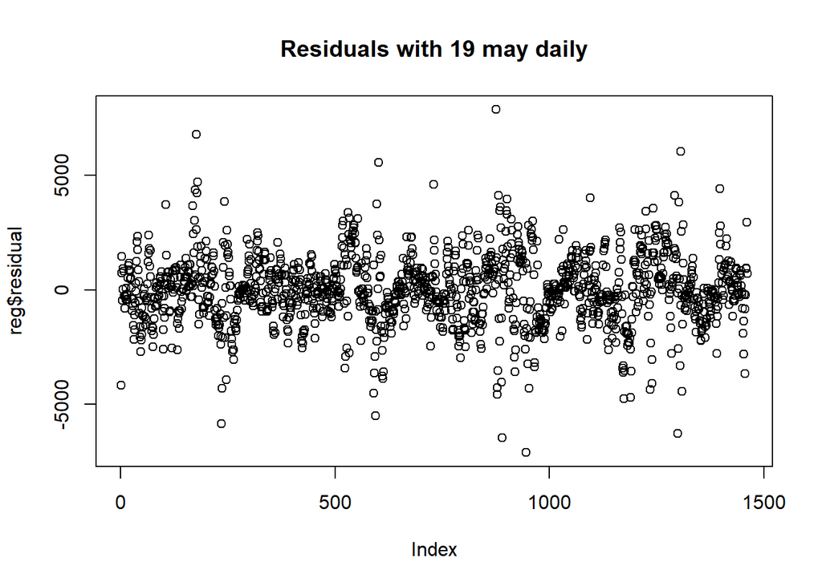

```r
plot(reg$residual,main="Residuals with 19 may daily")
```

```r
reg<-lm(differ~yeni_yil+yirmi_uc_nisan1+bir_mayis1+on_bes_temmuz1+yirmi_dokuz_ekim1+ramazan_bayrami1+kurban_bayrami1+covid,daily_consumption)
summary(reg)
```

```
##
## Call:
## lm(formula = differ ~ yeni_yil + yirmi_uc_nisan1 + bir_mayis1 +
##     on_bes_temmuz1 + yirmi_dokuz_ekim1 + ramazan_bayrami1 + kurban_bayrami1 +
##     covid, data = daily_consumption)
##
## Residuals:
##     Min      1Q  Median      3Q     Max
## -7129.4  -871.6   -11.0   846.5  8881.5
##
## Coefficients:
##                   Estimate Std. Error t value Pr(>|t|)
## (Intercept)          28.44      40.70   0.699 0.484861
## yeni_yil          -7306.98     778.19  -9.390  < 2e-16 ***
## yirmi_uc_nisan1   -2320.40     553.00  -4.196 2.88e-05 ***
## bir_mayis1        -2737.13     496.40  -5.514 4.15e-08 ***
## on_bes_temmuz1    -2965.73     777.13  -3.816 0.000141 ***
## yirmi_dokuz_ekim1 -2106.45     448.67  -4.695 2.92e-06 ***
## ramazan_bayrami1  -7998.21     252.13 -31.722  < 2e-16 ***
## kurban_bayrami1   -9108.96     259.04 -35.164  < 2e-16 ***
## covid             -1516.36     416.90  -3.637 0.000285 ***
## ---
## Signif. codes:  0 '***' 0.001 '**' 0.01 '*' 0.05 '.' 0.1 ' ' 1
##
## Residual standard error: 1554 on 1453 degrees of freedom
##   (21 observations deleted due to missingness)
## Multiple R-squared:  0.6256, Adjusted R-squared:  0.6235
## F-statistic: 303.5 on 8 and 1453 DF,  p-value: < 2.2e-16
```

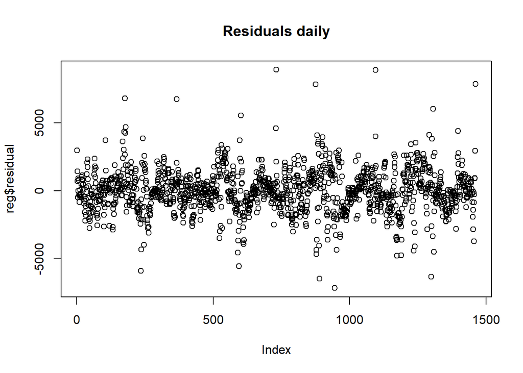

```r
plot(reg$residual,main="Residuals daily")
```

```r
reg1<-cbind(as.factor(daily_consumption$w_day),as.factor(daily_consumption$mon),as.factor(daily_consumption$y_day),daily_consumption$time_index,daily_consumption$yeni_yil1,daily_consumption$yirmi_uc_nisan1,daily_consumption$bir_mayis1,daily_consumption$on_bes_temmuz1,daily_consumption$yirmi_dokuz_ekim1,daily_consumption$ramazan_bayrami1,daily_consumption$kurban_bayrami1,daily_consumption$covid)
```

```r
unt_test=ur.kpss(daily_consumption$differ)
summary(unt_test)
```

```
##
## #######################
## # KPSS Unit Root Test #
## #######################
##
## Test is of type: mu with 7 lags.
##
## Value of test-statistic is: 0.0121
##
## Critical value for a significance level of:
##                 10pct  5pct 2.5pct  1pct
## critical values 0.347 0.463  0.574 0.739
```

```r
forecasted<-forecast(fitted1,h=14,xreg=tail(reg1,14))
forecasted$mean
```

```
## Time Series:
## Start = 1470
## End = 1483
## Frequency = 1
##   [1470,]   [1471,]   [1472,]   [1473,]   [1474,]   [1475,]   [1476,]   [1477,]
## 2543.5976 1999.6716 1423.7548  768.1909  175.0453 -286.4491 -603.5608 -781.9418
##   [1478,]   [1479,]   [1480,]   [1481,]   [1482,]   [1483,]
## -831.9090 -778.5679 -654.4503 -489.1834 -314.6184 -149.0751
```

With some data manipulation we try to fit the forecasted points to our data.

```r
daily_consumption[,forecast_differ:=c(rep(NA,7),fitted1$fitted,forecasted$mean)]

daily_consumption[Date<="2021-01-15",f2:=forecast_differ+shift(mean_consumption,7)]
daily_consumption[Date>"2021-01-15",f2:=tail(daily_consumption$forecast_differ,7)+daily_consumption[Date%between%as.Date(c("2021-01-09","2021-01-15")),f2]]

daily_consumption[,w_day:=weekdays(Date)]
daily_consumption[,y_day:=yday(Date)]
daily_consumption[,mon:=months(Date)]
daily_consumption[,time_index:=1:.N]

tail(daily_consumption,30)
```

```
##           Date mean_consumption      differ     w_day y_day    mon time_index
##  1: 2020-12-24         37143.41   639.22625  Perşembe   359 Aralık       1454
##  2: 2020-12-25         36367.12   171.06125      Cuma   360 Aralık       1455
##  3: 2020-12-26         33947.16   -96.82583 Cumartesi   361 Aralık       1456
##  4: 2020-12-27         30858.18  -201.82208     Pazar   362 Aralık       1457
##  5: 2020-12-28         35765.88  -796.07708 Pazartesi   363 Aralık       1458
##  6: 2020-12-29         35763.20 -1886.92458      Salı   364 Aralık       1459
##  7: 2020-12-30         36249.17 -1369.46708  Çarşamba   365 Aralık       1460
##  8: 2020-12-31         34342.43 -2800.97750  Perşembe   366 Aralık       1461
##  9: 2021-01-01         28998.90 -7368.21375      Cuma     1   Ocak       1462
## 10: 2021-01-02         30276.93 -3670.22083 Cumartesi     2   Ocak       1463
## 11: 2021-01-03         30023.36  -834.82333     Pazar     3   Ocak       1464
## 12: 2021-01-04         35548.28  -217.60250 Pazartesi     4   Ocak       1465
## 13: 2021-01-05         36723.26   960.05417      Salı     5   Ocak       1466
## 14: 2021-01-06         37182.32   933.15000  Çarşamba     6   Ocak       1467
```

[output cut: 145 more lines]

We read our actual values of the predicted period. We also need to do necessary operations needed in order to make our data usable. Then we take the mean of these dataset for daily consumption.

```r
consumption1<-fread("D:/Boğaziçi/İe360/data/hw4/RealTimeConsumption-09012021-22012021.csv")

consumption1[,Date:=as.Date(Date,format = "%d.%m.%Y")]
consumption1[,Consumption:=gsub('\\,','\\',Consumption)]
consumption1[,Consumption:=as.numeric(Consumption)]
consumption1
```

```
##            Date  Hour Consumption
##   1: 2021-01-09 00:00    34179.62
##   2: 2021-01-09 01:00    32540.12
##   3: 2021-01-09 02:00    31207.36
##   4: 2021-01-09 03:00    30300.31
##   5: 2021-01-09 04:00    29733.83
##  ---
## 332: 2021-01-22 19:00    41373.39
## 333: 2021-01-22 20:00    40013.85
## 334: 2021-01-22 21:00    39211.38
## 335: 2021-01-22 22:00    38496.36
## 336: 2021-01-22 23:00    37244.88
```

```r
daily_consumption1<-consumption1[,list(mean_consumption1=mean(Consumption,na.rm=T)),by=list(Date)]
daily_consumption1
```

```
##           Date mean_consumption1
##  1: 2021-01-09          34781.56
##  2: 2021-01-10          31841.90
##  3: 2021-01-11          36431.46
##  4: 2021-01-12          36897.99
##  5: 2021-01-13          37409.87
##  6: 2021-01-14          38056.05
##  7: 2021-01-15          38170.38
##  8: 2021-01-16          35667.35
##  9: 2021-01-17          32557.96
## 10: 2021-01-18          38447.89
## 11: 2021-01-19          39723.73
## 12: 2021-01-20          39960.92
## 13: 2021-01-21          39791.07
## 14: 2021-01-22          38902.97
```

After we predicted our data, we plot them on the same graph to see that whether they are similar or not.

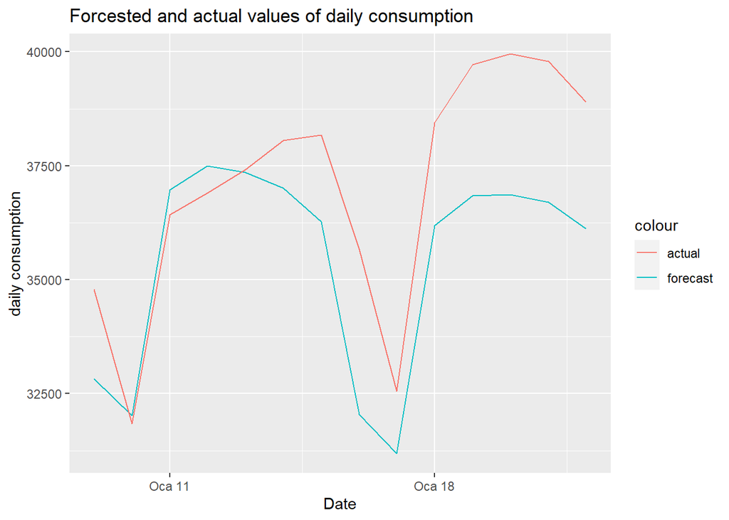

```r
ggplot() +
  geom_line(data=tail(daily_consumption,14),aes(x=Date,y=f2,color="forecast")) +
  geom_line(data=tail(daily_consumption1,14),aes(x=Date,y=mean_consumption1,color="actual")) +
  labs(xlab='Date(days)',ylab='Daily consumption', title='Forcested and actual values of daily consumption')+
  ylab("daily consumption")
```

After we predicted and plotted our values 14 days ahead it is time to look at their WMAPE value. The lower this value, our forecast will be more accurate.

```r
accu = function(actual, forecast){
  n = length(actual)
  error = actual - forecast
  mean = mean(actual)
  sd = sd(actual)
  FBias = sum(error)/sum(actual)
  MPE = sum(error/actual)/n
  MAPE = sum(abs(error/actual))/n
  RMSE = sqrt(sum(error^2)/n)
  MAD = sum(abs(error))/n
  WMAPE = MAD/mean
  return(data.frame(n,sd,FBias,MPE,MAPE,RMSE,MAD,WMAPE))
}

accu(daily_consumption1$mean_consumption1,tail(daily_consumption$f2,14))
```

```
##    n       sd     FBias       MPE      MAPE     RMSE     MAD      WMAPE
## 1 14 2567.339 0.0438552 0.0428573 0.0480873 2147.126 1812.53 0.04892674
```

## Conclusion

Our WMAPE value can be considered small. We may say that our prediction is successful. We thought that special holidays have an effect on consumption. We tried to make our data as stationary as possible by using these special holidays’ effect. There are some data which are not in special holidays but have low consumption values. By finding these values with some different approach we may make our data more stationary.